Introduction Avancée

Mickaël CANOUIL, *Ph.D.*

Dernière mise à jour : 2026-10-18

# Introduction à

## Installation de

Site internet officiel : https://www.r-project.org/

> R is a language and environment for statistical computing and graphics. It is a GNU project which is similar to the S language and environment which was developed at Bell Laboratories (formerly AT&T, now Lucent Technologies) by John Chambers and colleagues. R can be considered as a different implementation of S. There are some important differences, but much code written for S runs unaltered under R.

> R provides a wide variety of statistical (linear and nonlinear modelling, classical statistical tests, time-series analysis, classification, clustering, …) and graphical techniques, and is highly extensible. The S language is often the vehicle of choice for research in statistical methodology, and R provides an Open Source route to participation in that activity.

> One of R’s strengths is the ease with which well-designed publication-quality plots can be produced, including mathematical symbols and formulae where needed. Great care has been taken over the defaults for the minor design choices in graphics, but the user retains full control.

⇒ [**Download R**](https://cloud.r-project.org/)

## Sauvegarder le code …

### Pas l’environnement !

Les scripts :

- “*standards*”: `.R`.
- “*Rmarkdown*”:`.Rmd`.

Les “données” :

- “*objet*”: `.rds`.
- “*liste d’objet*”: `.Rdata`.

## Utiliser un IDE<sup>1</sup>

- RStudio :  
  https://www.rstudio.com/products/rstudio/download/#download
- Emacs + ESS :  
  https://ess.r-project.org
- vim + Nvim-R :  
  https://medium.com/free-code-camp/turning-vim-into-an-r-ide-cd9602e8c217
- Visual Studio Code + vscode-R :  
  https://github.com/REditorSupport/vscode-R
[^1]: “Integrated Development Environment”

## Faire *table rase* à chaque démarrage !

Lorsque vous quittez :

- Ne pas enregistrer votre espace de travail (*workspace*<sup>1</sup>) !

Lorsque vous démarrez :

- Ne pas charger l’espace de travail sauvegardé précédemment !
[^2]: Le *workspace* est automatiquement sauvegardé/chargé via un fichier nommé `.Rdata` (là où s’exécute ).

## Faire *table rase* !

### Dans Windows

[figure not shown]

## Faire *table rase* !

### Dans RStudio (*Tools > Global options*)

[figure not shown]

## Faire *table rase* !

- Dans un Terminal.

  ```bash
  R --no-save --no-restore-data
  ```

- `.bash_profile` / `.bashrc` / …

  ```bash
  alias R='R --no-save --no-restore-data'
  ```

## Comment Réinitialiser ?

### Avec `rm(list = ls())` ?

> If the first line of your R script is

> `rm(list = ls())`

> I will come into your office and SET YOUR COMPUTER ON FIRE 🔥.

> — Jenny Bryan

## Que ne fait pas `rm(list = ls())` ?

- Réinitialiser la session en cours
- Réinitialiser les `options()` → `options(stringsAsFactors = FALSE)`<sup>1</sup>
- Réinitialiser le répertoire de travail `getwd()` → `setwd()`
- Réinitialiser les extensions attachées
[^3]: Valeur par défaut v4.0.0 ([Kurt Hornik: stringsAsFactors](https://developer.r-project.org/Blog/public/2020/02/16/stringsasfactors/)).

## Alors que fait `rm(list = ls())` ?

```r
help(rm)
```

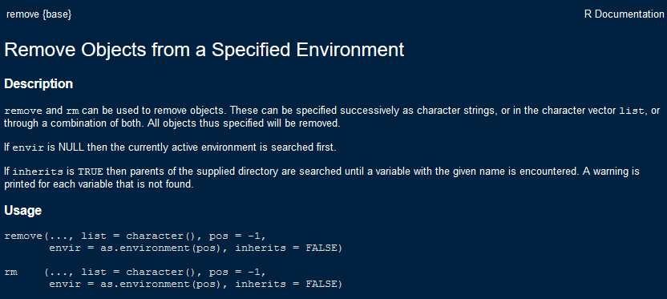

## Réinitialiser

- Dans une console
  - Via le raccourci `Ctrl+D`.
  - Via la fonction `q()` dans une console .

## Réinitialiser

- Dans RStudio :
  - Via le raccourci `Ctrl+Shift+F10`.
  - Via le menu.

[figure not shown]

## Désactiver les fichiers de démarrage

- `--vanilla`,  
  pour désactiver le chargement de **tous les fichiers** de démarrage.
- `--no-init-file`,  
  pour désactiver le chargement du fichier `.Rprofile`.
- `--no-environ`,  
  pour désactiver le chargement du fichier `.Renviron`.

## `setwd(...)` en première ligne …

> If the first line of your R script is

> `setwd("C:\Users\jenny\path\that\only\I\have")`

> I will come into your office and SET YOUR COMPUTER ON FIRE 🔥.

> — Jenny Bryan

## Faisons le Point sur `setwd()` !

```r
library(ggplot2)

setwd("/path/to/a/directory/on/my/laptop/data")

df <- read.delim("data.csv")

p <- ggplot(df, aes(x, y)) + geom_point()

ggsave("../figs/scatterplot.png")
```

```r
library(ggplot2)

setwd("/path/to/a/directory/on/my/laptop/data")

df <- read.delim("data.csv")

p <- ggplot(df, aes(x, y)) + geom_point()

setwd("/path/to/a/directory/on/my/laptop/figs")

ggsave("scatterplot.png")
```

## L’extension `here`

```r
here::here()
here::i_am("radvanced.qmd")
here::i_am("contents/content-01.qmd")
```

## Utiliser un Mode “Projet” via un IDE

- Démarrer un projet A :
  1. Démarre R.
  2. Défini le répetoire de travail de R comme la racine du projet A.
- Passer d’un projet A à un project B :
  1. Redémarre R.
  2. Défini le répetoire de travail de R comme la racine du projet B.

## Utiliser un Mode “Projet”

- [**“What They Forgot to Teach You About R”**](https://rstats.wtf/project-oriented-workflow.html)  
  — Jenny Bryan & Jim Hester
- [**“Project-oriented Workflow”**](https://www.tidyverse.org/articles/2017/12/workflow-vs-script/)  
  — Jenny Bryan

## Lectures Utiles

- [**“Code Smells and Feels”**](https://www.youtube.com/watch?v=7oyiPBjLAWY)  
  — Jenny Bryan
- [**“Advanced R”**](https://adv-r.hadley.nz/)  
  — Hadley Wickham
- [**“Project-oriented Workflow”**](https://www.tidyverse.org/articles/2017/12/workflow-vs-script/)  
  — Jenny Bryan
- [**“R for Data Science”**](https://r4ds.had.co.nz/)  
  — Garrett Grolemund & Hadley Wickham
- [**“What They Forgot to Teach You About R”**](https://rstats.wtf/)  
  — Jenny Bryan & Jim Hester

# Fondamentaux “ base” Noms et Valeurs

## Affectation

```r
x <- c(1, 2, 3)
```

“Crée un objet nommé ‘x’, contenant les valeurs 1, 2 et 3” ou plus précisément :

- Crée un objet de type vecteur `c(1, 2, 3)`.
- Associe cet objet à un nom `x`.

## Affectation

```r
x <- c(1, 2, 3)
y <- x
```

```r
lobstr::obj_addr(x)
```

```
[1] "0x5595ed645328"
```

```r
lobstr::obj_addr(y)
```

```
[1] "0x5595ed645328"
```

`y` n’est pas une copie de `x`. `x` et `y` sont des références à l’objet de type vecteur `c(1, 2, 3)`.

## Noms Non-syntaxique

dispose d’un ensemble de règles pour les noms utilisables :

- Contient uniquement des lettres (ASCII, mais pas uniquement), des chiffres, `.` et `_`.
- Ne peut pas débuter par des chiffres ou `_`.
- Ne peut pas être un “nom réservé” (`?Reserved`).

## Noms Non-syntaxique

```r
_abc <- 1
```

```
Error in parse(text = input): <text>:1:2: unexpected symbol
1: _abc
     ^
```

```r
TRUE <- "false"
```

```
Error in `TRUE <- "false"`:
! invalid (do_set) left-hand side to assignment
```

```r
(`_abc` <- 1)
```

```
[1] 1
```

```r
(`+` <- 1)
```

```
[1] 1
```

## Exercices

1. Expliquer les relations entre `a`, `b`, `d` et `e`.

   ```r
   a <- 1:10
   b <- a
   b -> e
   e <- d <- 1:10
   ```

2. Que donne le code suivant pour importer un “fichier” csv ?  
   Quel argument faudrait-il utiliser pour avoir les noms des colonnes tels-qu’ils sont ?

   ```r
   read.csv(
     header = TRUE,
     text = "1ere_colonne,deuxième_colonne,troisième colonne\n1,2,3"
   )
   ```

3. Les fonctions `read.*()` utilisent `make.names()` ?  
   Quels sont les règles de conversions utilisées ?

## Copie sur Modification<sup>1</sup>

```r
x <- c(1, 2, 3)
y <- x

y[3] <- 4
x
```

```
[1] 1 2 3
```

```r
y
```

```
[1] 1 2 4
```

La modification de `y` n’a pas modifié `x`.  
crée une copie de l’objet référencé par `x` en modifiant la troisième valeur.  
Ce nouvel objet est ensuite référencé par `y`.

[^4]: “Copy-on-modify”

## Déréférencement et “Garbage Collection”

```r
x <- 1:3
x <- 2:4

rm(x) # Déréférencement

gc() # Force "Garbage Collection"
```

```
          used (Mb) gc trigger (Mb) max used (Mb)
Ncells  717841 38.4    1326914 70.9  1326914 70.9
Vcells 1335251 10.2    8388608 64.0  2051244 15.7
```

## Exercices

1. À quelle ligne, une copie de `a` est effectuée ?

   ```r
   a <- c(1, 5, 3, 2)
   b <- a
   b[[1]] <- 10
   ```

# Fondamentaux “ base” Les Vecteurs

## Les Vecteurs

- Booléen : `TRUE` et `FALSE`.
- Numérique
  - Flottant (“double”)
    - Décimal `0.1234`.
    - Scientifique `1.23e4`.
    - Hexadécimal `0xcafe`.
    - Valeurs particulières : `Inf`, `-Inf` et `NaN`.
  - Entier (“integer”) : suffixe `L`, *p.ex.*, `123L`, `1.23e4L` et `0xcafeL`.
- Chaîne de caractères : entourées par `"` ou `'`.  
  Les caractères spéciaux sont échappés par `\` (`?Quotes`).

## Les Vecteurs

`c()` (“combine”) permet de constituer des vecteurs de longueurs supérieurs à 1.

```r
lgl_var <- c(TRUE, FALSE)
int_var <- c(1L, 6L, 10L)
dbl_var <- c(1, 2.5, 4.5)
chr_var <- c("these are", "some strings")
```

Lorsque les éléments de `c()` sont dit atomiques, le résultat est alors de même nature.

```r
c(c(1, 2), c(3, 4))
```

```
[1] 1 2 3 4
```

## Les Vecteurs

Le type d’un vecteur peut-être déterminé via `typeof()`.

```r
typeof(lgl_var)
```

```
[1] "logical"
```

```r
typeof(int_var)
```

```
[1] "integer"
```

```r
typeof(dbl_var)
```

```
[1] "double"
```

```r
typeof(chr_var)
```

```
[1] "character"
```

## Les Vecteurs

Et sa longueur via `length()`.

```r
length(lgl_var)
```

```
[1] 2
```

```r
length(int_var)
```

```
[1] 3
```

```r
length(dbl_var)
```

```
[1] 3
```

```r
length(chr_var)
```

```
[1] 2
```

## Valeurs Manquantes

symbolise les valeurs manquantes à l’aide de `NA` (“not applicable”).  
Un calcul impliquant `NA` résultera en un `NA`.

```r
NA > 5
```

```
[1] NA
```

```r
10 * NA
```

```
[1] NA
```

```r
!NA
```

```
[1] NA
```

## Valeurs Manquantes

À quelques exceptions.

```r
NA ^ 0
```

```
[1] 1
```

```r
NA | TRUE
```

```
[1] TRUE
```

```r
NA & FALSE
```

```
[1] FALSE
```

## Valeurs Manquantes

Détermination des valeurs manquantes d’un vecteur de façon “naïve”.

```r
x <- c(NA, 5, NA, 10)
x == NA
```

```
[1] NA NA NA NA
```

La bonne approche pour éviter les erreurs.

```r
is.na(x)
```

```
[1]  TRUE FALSE  TRUE FALSE
```

## Valeurs Manquantes

`NA` est la forme “générique”, mais il existe un `NA` pour chacun des types :

- Booléen : `NA`.
- Numérique
  - Flottant (“double”) : `NA_real_`.
  - Entier (“integer”) : `NA_integer_`.
- Chaîne de caractères : `NA_character_`.

## Test et Conversion de Type

dispose de fonctions `is.*()` pour tester le type d’un vecteur, mais sont à utiliser avec précautions.

`is.logical()`, `is.integer()`, `is.double()` et `is.character()` effectueront bien le test demandé/attendu.

Ce qui ne sera pas nécessairement le cas de `is.vector()`, `is.atomic()` et `is.numeric()`.

```r
?is.numeric
```

> is.numeric is an internal generic primitive function: you can write methods to handle specific classes of objects, see InternalMethods. It is not the same as is.double. Factors are handled by the default method, and there are methods for classes “Date”, “POSIXt” and “difftime” (all of which return false). Methods for is.numeric should only return true if the base type of the class is double or integer and values can reasonably be regarded as numeric (e.g., arithmetic on them makes sense, and comparison should be done via the base type).

## Test et Conversion de Type

Un vecteur ne dispose que d’un seul type, c’est-à-dire, tous les éléments doivent avoir le même type.

Lorsque les éléments d’un vecteur sont de plusieurs types, une conversion sera appliquée selon la règle de priorité :  
`character` → `double` → `integer` → `logical`.

```r
x <- c("a", 1)
typeof(x)
```

```
[1] "character"
```

```r
str(x)
```

```
 chr [1:2] "a" "1"
```

## Test et Conversion de Type

La plupart des fonctions mathématiques réalise cette conversion de type (*p.ex.*, `+`, `log`, etc.).

```r
x <- c(FALSE, FALSE, TRUE)
as.numeric(x)
```

```
[1] 0 0 1
```

```r
# Nombre de "TRUE"
sum(x)
```

```
[1] 1
```

```r
# Proportion de "TRUE"
mean(x)
```

```
[1] 0.3333333
```

## Test et Conversion de Type

Il est possible de convertir explicitement un vecteur avec les fonctions `as.*()` : `as.logical()`, `as.integer()`, `as.double()` et `as.character()`.

avertira via un avertissement d’un problème lors de la conversion.

```r
as.integer(c("1", "1.5", "a"))
```

```
Warning: NAs introduced by coercion
```

```
[1]  1  1 NA
```

## Exercices

1. Déterminer le type des vecteurs suivants.

   ```r
   c(1, FALSE)
   c("a", 1)
   c(TRUE, 1L)
   ```

2. Déterminer le résultat des comparaisons suivantes.

   ```r
   1 == "1"
   -1 < FALSE
   "one" < 2
   ```

   Pour quelle raison ces résultats ont été obtenu ?
3. Pourquoi le type par défaut de `NA` est booléen ?

# Fondamentaux “ base” Les Attributs

## Les Attributs

Les attributs sont des meta-données stockées sont la forme de paire nom/valeur.  
Chaque attribut peut être récupéré et défini individuellement via `attr()`, récupéré en masse via `attributes()` ou encore défini en masse via `structure()`.

```r
a <- 1:3
attr(a, "x") <- "abcdef"
attr(a, "x")
```

```
[1] "abcdef"
```

```r
attr(a, "y") <- 4:6
str(attributes(a))
```

```
List of 2
 $ x: chr "abcdef"
 $ y: int [1:3] 4 5 6
```

## Les Attributs

```r
a <- structure(
  1:3,
  x = "abcdef",
  y = 4:6
)
str(attributes(a))
```

```
List of 2
 $ x: chr "abcdef"
 $ y: int [1:3] 4 5 6
```

## Les Attributs

Les attributs sont en général éphémères, dans le sens où ils sont perdus dans la plupart des opérations.

```r
attributes(a[1])
```

```r
attributes(sum(a))
```

Là encore, il y a principalement deux exceptions :

- **noms** (`names`), un vecteur de chaîne de caractères donnant le nom de chaque élément.
- **dimension** (`dim`), un vecteur de valeurs entières donnant les dimensions (utilisé dans la conversion des vecteurs en matrices ou “arrays”).

## Les Attributs : Noms

Il existe plusieurs façons de nommer les éléments d’un vecteur.

- Lors de la création.

  ```r
  x <- c(a = 1, b = 2, c = 3)
  ```

- Avec `names()` pour affecter des un vecteur de chaîne de caractères.

  ```r
  x <- 1:3
  names(x) <- c("a", "b", "c")
  ```

- Avec `setNames()`, pour réaliser la même tâche en une seule ligne.

  ```r
  x <- setNames(1:3, c("a", "b", "c"))
  ```

## Les Attributs : Dimensions

- Les vecteurs sont de dimension `NULL`.

  ```r
  dim(1:6)
  ```

- Les matrices sont de dimension `2`.

  ```r
  x <- matrix(1:6, nrow = 2, ncol = 3)
  dim(x)
  ```

  ```
  [1] 2 3
  ```

- Les “arrays” sont de dimension `n`.

  ```r
  x <- array(1:12, dim = c(2, 3, 2))
  dim(x)
  ```

  ```
  [1] 2 3 2
  ```

## Les Attributs : Dimensions

Il est possible de modifier directement les dimensions d’un vecteur pour en modifier la “forme”.

```r
x <- 1:6
dim(x) <- c(3, 2)
x
```

```
     [,1] [,2]
[1,]    1    4
[2,]    2    5
[3,]    3    6
```

## Les Attributs : Dimensions

| Vector | Matrix | Array |
| --- | --- | --- |
| names() | rownames(), colnames() | dimnames() |
| length() | nrow(), ncol() | dim() |
| c() | rbind(), cbind() | abind::abind() |
| --- | t() | aperm() |
| is.null(dim(x)) | is.matrix() | is.array() |

## Les Attributs : Dimensions

`str()` est le meilleur moyen d’identifier la “nature” d’un objet.

```r
str(1:3)                   # 1d vector
```

```
 int [1:3] 1 2 3
```

```r
str(matrix(1:3, ncol = 1)) # column vector
```

```
 int [1:3, 1] 1 2 3
```

```r
str(matrix(1:3, nrow = 1)) # row vector
```

```
 int [1, 1:3] 1 2 3
```

```r
str(array(1:3, 3))         # "array" vector
```

```
 int [1:3(1d)] 1 2 3
```

# Fondamentaux “ base” Les Vecteurs (Objets) S3

## Les Vecteurs (Objets) S3

`class` est un autre attribut important dans , il est le fondement du système objet S3.

Un objet possédant l’attribut `class` devient un **objet S3** qui réagira différemment d’un simple objet au regard d’une fonction dite “générique”.

Les principaux vecteurs S3 :

- `factor`, permettant de définir des niveaux pour un vecteur.
- `Date`, la date dans un format défini au jour près.
- `POSIXct`, la date dans un format défini à la seconde près.

## Les Vecteurs (Objets) S3 : Les Facteurs

Un facteur est un vecteur ne pouvant contenir que des valeurs prédéfinies.  
Ce type de vecteur est utilisé pour stocker des données catégorielles / discrètes en se basant sur un vecteur d’entier.

```r
x <- factor(c("a", "b", "b", "a"))
x
```

```
[1] a b b a
Levels: a b
```

```r
typeof(x)
```

```
[1] "integer"
```

## Les Vecteurs (Objets) S3 : Les Facteurs

Un facteur est un vecteur ne pouvant contenir que des valeurs prédéfinies.  
Ce type de vecteur est utilisé pour stocker des données catégorielles / discrètes en se basant sur un vecteur d’entier.

```r
attributes(x)
```

```
$levels
[1] "a" "b"

$class
[1] "factor"
```

```r
str(x)
```

```
 Factor w/ 2 levels "a","b": 1 2 2 1
```

## Les Vecteurs (Objets) S3 : Les Facteurs

Les niveaux d’un facteur peuvent être connus, mais pas nécessairement observés dans les données.

```r
sex_char <- c("m", "m", "m")
sex_factor <- factor(sex_char, levels = c("m", "f"))
```

Ainsi, il est possible de compter les occurrences de l’ensemble des niveaux.

```r
table(sex_char)
```

```
sex_char
m
3
```

```r
table(sex_factor)
```

```
sex_factor
m f
3 0
```

## Les Vecteurs (Objets) S3 : Les Facteurs

Les facteurs peuvent également être ordonnées et se comportent comme des facteurs “classiques”.

```r
ordered(c("b", "b", "a", "c"), levels = c("c", "b", "a"))
```

```
[1] b b a c
Levels: c < b < a
```

```r
factor( c("b", "b", "a", "c"), levels = c("c", "b", "a"), ordered = TRUE)
```

```
[1] b b a c
Levels: c < b < a
```

**Note :** Les fonctions `read.*()` et `data.frame()` convertissent automatique les vecteurs de chaîne de caractères en facteurs.  
Il est recommandé de désactiver ce comportant `options(stringsAsFactors = FALSE)` (Par défaut avec `R > 4.0`).

## Exercices

1. Quelle sorte d’objet renvoi `table()` ?  
   Quel est son type ?  
   Quels sont ses attributs ?
2. Qu’arrive-t-il à un facteur lorsque les niveaux sont modifiés ?

   ```r
   f1 <- factor(letters)
   levels(f1) <- rev(levels(f1))
   ```

3. Que fait le code suivant ?  
   De quelle façon `f2` et `f3` différent-ils de `f1` ?

   ```r
   f2 <- rev(factor(letters))
   f3 <- factor(letters, levels = rev(letters))
   ```

# Fondamentaux “ base” Les Listes

## Les Listes

À la différence des vecteurs, les éléments d’une liste peuvent être de n’importe quel type, il n’est plus question de “cohérence de type”.

```r
l1 <- list(
  1:3,
  "a",
  c(TRUE, FALSE, TRUE),
  c(2.3, 5.9)
)
typeof(l1)
```

```
[1] "list"
```

## Les Listes

À la différence des vecteurs, les éléments d’une liste peuvent être de n’importe quel type, il n’est plus question de “cohérence de type”.

```r
str(l1)
```

```
List of 4
 $ : int [1:3] 1 2 3
 $ : chr "a"
 $ : logi [1:3] TRUE FALSE TRUE
 $ : num [1:2] 2.3 5.9
```

## Les Listes

Chaque élément d’une liste, n’est en réalité qu’une référence à l’objet.

```r
lobstr::obj_size(mtcars)
```

```
7.21 kB
```

```r
l2 <- list(mtcars, mtcars, mtcars, mtcars)
lobstr::obj_size(l2)
```

```
7.29 kB
```

## Les Listes

La levée de la contrainte de “cohérence de type” fait des listes un type particulièrement flexible et de ce fait ne permet pas d’avoir une représentation générique efficace systématiquement, comme c’est le cas pour les vecteurs.

```r
l3 <- list(list(list(1)))
str(l3)
```

```
List of 1
 $ :List of 1
  ..$ :List of 1
  .. ..$ : num 1
```

## Les Listes

`c()` permet de combiner des éléments dans le cas des listes.

```r
l4 <- list(list(1, 2), c(3, 4))
str(l4)
```

```
List of 2
 $ :List of 2
  ..$ : num 1
  ..$ : num 2
 $ : num [1:2] 3 4
```

```r
l5 <- c(list(1, 2), c(3, 4))
str(l5)
```

```
List of 4
 $ : num 1
 $ : num 2
 $ : num 3
 $ : num 4
```

## Test et Conversion de Type

Le `typeof()` d’une liste est `list`. `is.list()` permet de tester si l’objet est une liste quand `as.list()` permet la conversion en liste.

```r
list(1:3)
```

```
[[1]]
[1] 1 2 3
```

```r
as.list(1:3)
```

```
[[1]]
[1] 1

[[2]]
[1] 2

[[3]]
[1] 3
```

## Matrices et Arrays

L’attribut `dim` permettait de passer d’un vecteur à une matrice ou à un array.  
Dans le cas des listes, il permet de passer à des “matrice-liste” et “array-liste”.

```r
l <- list(1:3, "a", TRUE, 1.0)
dim(l) <- c(2, 2)
l
```

```
     [,1]      [,2]
[1,] integer,3 TRUE
[2,] "a"       1
```

```r
l[[1, 1]]
```

```
[1] 1 2 3
```

## Exercices

1. Lister les points de divergences entre un vecteur et une liste.
2. Pourquoi `as.vector()` ne fonctionne pas pour convertir une liste en vecteur ?  
   Pourquoi l’usage de `unlist()` est nécessaire ?

# Fondamentaux “ base” Les `data.frame`

## `data.frame`

L’une des classes S3 importante dans est la classe `data.frame` (`tibble` dans le “tidyverse”), qui repose entièrement sur les listes.

Qu’est-ce qu’un `data.frame` ?

```r
df1 <- data.frame(x = 1:3, y = letters[1:3])
typeof(df1)
```

```
[1] "list"
```

Un `data.frame` est une liste nommée, de vecteur de même dimension (longueur) avec des attributs `names` (noms des colonnes) et `row.names`.

## `data.frame`

L’une des classes S3 importante dans est la classe `data.frame` (`tibble` dans le “tidyverse”), qui repose entièrement sur les listes.

Qu’est-ce qu’un `data.frame` ?

```r
attributes(df1)
```

```
$names
[1] "x" "y"

$class
[1] "data.frame"

$row.names
[1] 1 2 3
```

Un `data.frame` est une liste nommée, de vecteur de même longueur avec des attributs `names` (noms des colonnes) et `row.names`.

## `data.frame`

Un `data.frame` a donc une structure rectangulaire et dispose de noms pour les lignes et les colonnes.

- `rownames()` pour obtenir le noms des lignes.
- `colnames()` (ou `names()`) pour obtenir le noms des colonnes.
- `nrow()` pour obtenir le nombre de lignes.
- `ncol()` (ou `length()`) pour obtenir le nombre de colonnes.

## `data.frame`

La création d’un `data.frame` se fait via `data.frame()`.

```r
df <- data.frame(
  x = 1:3,
  y = c("a", "b", "c")
)
str(df)
```

```
'data.frame':   3 obs. of  2 variables:
 $ x: int  1 2 3
 $ y: chr  "a" "b" "c"
```

## `data.frame`

La création d’un `data.frame` se fait via `data.frame()`.

```r
df <- data.frame(
  x = 1:3,
  y = c("a", "b", "c"),
  stringsAsFactors = TRUE # Par défaut dans R < 4.0
)
str(df)
```

```
'data.frame':   3 obs. of  2 variables:
 $ x: int  1 2 3
 $ y: Factor w/ 3 levels "a","b","c": 1 2 3
```

## `data.frame`

La création d’un `data.frame` se fait via `data.frame()`.

```r
df <- data.frame(
  x = 1:3,
  y = c("a", "b", "c"),
  stringsAsFactors = FALSE # Par défaut dans R > 4.0
)
str(df)
```

```
'data.frame':   3 obs. of  2 variables:
 $ x: int  1 2 3
 $ y: chr  "a" "b" "c"
```

## `data.frame`

Par défaut, un `data.frame` requiert des noms de colonnes syntaxiquement correct.

```r
names(data.frame(`1` = 1))
```

```
[1] "X1"
```

```r
names(data.frame(`1` = 1, check.names = FALSE))
```

```
[1] "1"
```

## `data.frame`

Un `data.frame` requiert que ces éléments soit de même longueur, quand cela n’est pas respecté et lorsque c’est possible, les valeurs des vecteurs les plus courts sont recyclés.

```r
data.frame(x = 1:4, y = 1:2)
```

```
  x y
1 1 1
2 2 2
3 3 1
4 4 2
```

```r
data.frame(x = 1:4, y = 1:3)
```

```
Error in `data.frame()`:
! arguments imply differing number of rows: 4, 3
```

## `data.frame`

Les `data.frame` ayant des noms de lignes, il est possible de les définir de plusieurs façons.

```r
df3 <- data.frame(
  age = c(35, 27, 18),
  hair = c("blond", "brown", "black"),
  row.names = c("Bob", "Susan", "Sam")
)
df3
```

```
      age  hair
Bob    35 blond
Susan  27 brown
Sam    18 black
```

## `data.frame`

Les `data.frame` ayant des noms de lignes, il est possible de les définir de plusieurs façons.

```r
df3 <- data.frame(
  age = c(35, 27, 18),
  hair = c("blond", "brown", "black")
)
rownames(df3) <- c("Bob", "Susan", "Sam")
df3
```

```
      age  hair
Bob    35 blond
Susan  27 brown
Sam    18 black
```

## `data.frame`

L’usage des noms de lignes n’est pas recommandé.

- Le nom des lignes est une donnée, pourquoi la stocker différemment ?
- Le nom des lignes doit obligatoirement être une chaîne de caractères.
- Chaque nom de ligne doit-être unique.  
  s’assurera que ce soit le cas !

  ```r
  df3[c(1, 1, 1), ]
  ```

  ```
        age  hair
  Bob    35 blond
  Bob.1  35 blond
  Bob.2  35 blond
  ```

## Test et Conversion de Type

`is.data.frame()` permet de tester si l’objet est un `data.frame()` quand `as.data.frame()` permet la conversion.

```r
is.data.frame(df1)
```

```
[1] TRUE
```

## Exercises

1. Est-il possible d’avoir un `data.frame` avec zéro lignes ?  
   Et zéro colonnes ?
2. Que se passe-t-il lorsque des noms lignes avec duplicatas sont définis via `rownames()` ?
3. Que donne `t(df)` ou `t(t(df))` ?  
   Avec, `df` un objet de classe `data.frame`.
4. Que fait `as.matrix()` sur un `data.frame` dont les colonnes sont de type différents ?

# Fondamentaux “ base” `NULL`

## `NULL`

`NULL` un objet particulier.

```r
typeof(NULL)
```

```
[1] "NULL"
```

```r
length(NULL)
```

```
[1] 0
```

```r
x <- NULL
attr(x, "y") <- 1
```

```
Error in `attr(x, "y") <- 1`:
! attempt to set an attribute on NULL
```

## `NULL`

Il est possible de tester le caractère `NULL` d’un objet.

```r
is.null(NULL)
```

```
[1] TRUE
```

`NULL` sert à définir :

- un vecteur vide (*p.ex.*, `c()`).
- un vecteur absent (*p.ex.*, argument non défini d’une fonction).

# Fondamentaux “ base” Sélection

## Sélection Dans un Vecteur

- Entier positif.

  ```r
  x <- c(2.1, 4.2, 3.3, 5.4)
  ```

  ```r
  x[c(3, 1)]
  ```

  ```
  [1] 3.3 2.1
  ```

  ```r
  x[c(1, 1)]
  ```

  ```
  [1] 2.1 2.1
  ```

  ```r
  x[c(2.1, 2.9)] # Troncature
  ```

  ```
  [1] 4.2 4.2
  ```

## Sélection Dans un Vecteur

- Entier négatif.

  ```r
  x <- c(2.1, 4.2, 3.3, 5.4)
  ```

  ```r
  x[-c(3, 1)]
  ```

  ```
  [1] 4.2 5.4
  ```

  ```r
  x[c(-1, 2)] # Pas de mélange
  ```

  ```
  Error in `x[c(-1, 2)]`:
  ! only 0's may be mixed with negative subscripts
  ```

## Sélection Dans un Vecteur

- Booléen.

  ```r
  x <- c(2.1, 4.2, 3.3, 5.4)
  ```

  ```r
  x[c(TRUE, TRUE, FALSE, FALSE)]
  ```

  ```
  [1] 2.1 4.2
  ```

  ```r
  x[x > 3]
  ```

  ```
  [1] 4.2 3.3 5.4
  ```

## Sélection Dans un Vecteur

- Recyclage des valeurs.

  ```r
  x <- c(2.1, 4.2, 3.3, 5.4)
  ```

  ```r
  x[c(TRUE, FALSE)] # Recyclage
  ```

  ```
  [1] 2.1 3.3
  ```

  ```r
  x[c(TRUE, FALSE, TRUE, FALSE)]
  ```

  ```
  [1] 2.1 3.3
  ```

## Sélection Dans un Vecteur

- Valeur manquante.

  ```r
  x <- c(2.1, 4.2, 3.3, 5.4)
  ```

  ```r
  x[c(TRUE, TRUE, NA, FALSE)]
  ```

  ```
  [1] 2.1 4.2  NA
  ```

## Sélection Dans un Vecteur

- “Rien”.

  ```r
  x <- c(2.1, 4.2, 3.3, 5.4)
  ```

  ```r
  x[]
  ```

  ```
  [1] 2.1 4.2 3.3 5.4
  ```

## Sélection Dans un Vecteur

- Zéro.

  ```r
  x <- c(2.1, 4.2, 3.3, 5.4)
  ```

  ```r
  x[0]
  ```

  ```
  numeric(0)
  ```

## Sélection Dans un Vecteur

- Avec des “noms”.

  ```r
  x <- c(2.1, 4.2, 3.3, 5.4)
  names(x) <- letters[1:4]
  ```

  ```r
  x[c("d", "c", "a")]
  ```

  ```
    d   c   a
  5.4 3.3 2.1
  ```

  ```r
  x[c("a", "a", "a")]
  ```

  ```
    a   a   a
  2.1 2.1 2.1
  ```

## Sélection Dans un Vecteur

- Avec des “noms”, une correspondance parfaite est requise.

  ```r
  z <- c(abc = 1, def = 2)
  ```

  ```r
  z[c("a", "d")] # Correspondance parfaite
  ```

  ```
  <NA> <NA>
    NA   NA
  ```

  ```r
  z[c("abc", "def")]
  ```

  ```
  abc def
    1   2
  ```

## Sélection Dans une Liste

La sélection s’opère de la même façon que sur un vecteur.

- `[`, renvoi une liste.
- `[[` et `$`, renvoient un élément d’une liste.

## Sélection Dans une Liste

La sélection s’opère de la même façon que sur un vecteur.

- `[`, renvoi une liste.

  ```r
  x <- list(2.1, 4.2, 3.3, 5.4)
  x[c(1, 3)]
  ```

  ```
  [[1]]
  [1] 2.1

  [[2]]
  [1] 3.3
  ```

  ```r
  x[[2]]
  ```

  ```
  [1] 4.2
  ```

## Sélection Dans une Liste

La sélection s’opère de la même façon que sur un vecteur.

- `[[` et `$`, renvoient un élément d’une liste.

  ```r
  x <- list(2.1, 4.2, 3.3, 5.4)
  names(x) <- letters[1:4]
  x$a
  ```

  ```
  [1] 2.1
  ```

  ```r
  x[["b"]]
  ```

  ```
  [1] 4.2
  ```

## Sélection Dans une Matrice ou Array

La sélection peut s’effectuer avec un vecteur, plusieurs vecteurs ou une matrice.

```r
a <- matrix(1:9, nrow = 3)
colnames(a) <- c("A", "B", "C")
a[1:2, ]
```

```
     A B C
[1,] 1 4 7
[2,] 2 5 8
```

```r
a[c(TRUE, FALSE, TRUE), c("B", "A")]
```

```
     B A
[1,] 4 1
[2,] 6 3
```

## Sélection Dans une Matrice ou Array

Comme les matrices ou arrays ne sont que des vecteurs avec un attribut `dim`, la sélection peut se faire directement avec un seul vecteur de position.

```r
vals <- outer(1:5, 1:5, FUN = "paste", sep = ",")
vals
```

```
     [,1]  [,2]  [,3]  [,4]  [,5]
[1,] "1,1" "1,2" "1,3" "1,4" "1,5"
[2,] "2,1" "2,2" "2,3" "2,4" "2,5"
[3,] "3,1" "3,2" "3,3" "3,4" "3,5"
[4,] "4,1" "4,2" "4,3" "4,4" "4,5"
[5,] "5,1" "5,2" "5,3" "5,4" "5,5"
```

```r
vals[c(4, 15)]
```

```
[1] "4,1" "5,3"
```

## Sélection Dans une Matrice ou Array

Il est également possible d’effectuer la sélection à partir d’une matrice donnant la position des dans chacune des dimensions de la matrice ou array que l’on souhaite manipuler.

```r
vals <- outer(1:5, 1:5, FUN = "paste", sep = ",")
select <- matrix(ncol = 2, byrow = TRUE, c(
  1, 1,
  3, 1,
  2, 4
))
vals[select]
```

```
[1] "1,1" "3,1" "2,4"
```

## Sélection Dans un `data.frame`

Les `data.frame` se comportent comme des listes et comme des matrices.

```r
df <- data.frame(x = 1:3, y = 3:1, z = letters[1:3])
df[df$x == 2, ]
```

```
  x y z
2 2 2 b
```

```r
df[c(1, 3), ]
```

```
  x y z
1 1 3 a
3 3 1 c
```

## Sélection Dans un `data.frame`

Deux approches pour sélectionner les colonnes d’un `data.frame`.

```r
df <- data.frame(x = 1:3, y = 3:1, z = letters[1:3])
df[c("x", "z")] # approche liste
```

```
  x z
1 1 a
2 2 b
3 3 c
```

```r
df[, c("x", "z")] # approche matrice
```

```
  x z
1 1 a
2 2 b
3 3 c
```

## Sélection Dans un `data.frame`

Attention, ces deux approches ne sont pas tout à fait équivalentes.

```r
str(df["x"])
```

```
'data.frame':   3 obs. of  1 variable:
 $ x: int  1 2 3
```

```r
str(df[, "x"])
```

```
 int [1:3] 1 2 3
```

```r
str(df[, "x", drop = FALSE])
```

```
'data.frame':   3 obs. of  1 variable:
 $ x: int  1 2 3
```

## Exercices

1. Corriger les erreurs dans les codes suivants.

   ```r
   mtcars[mtcars$cyl = 4, ]
   mtcars[-1:4, ]
   mtcars[mtcars$cyl <= 5]
   mtcars[mtcars$cyl == 4 | 6, ]
   ```

2. Pourquoi le code suivant renvoi cinq valeurs manquantes ?  
   Et avec `x[NA_real_]` ?

   ```r
   x <- 1:5
   x[NA]
   ```

   ```
   [1] NA NA NA NA NA
   ```

3. Pourquoi `mtcars[1:20]` produit une erreur alors que `mtcars[1:20, ]` fonctionne ?  
   Quelle est la différence ?
4. Que fait `df[is.na(df)] <- 0` ?  
   Sur quel principe repose cette commande ?

## Les Opérateurs `[[` et `$`

`[[` renvoi toujours un élément plus petit.

```r
x <- list(1:3, "a", 4:6)
x[1]
```

```
[[1]]
[1] 1 2 3
```

```r
x[[1]]
```

```
[1] 1 2 3
```

## Les Opérateurs `[[` et `$`

`$` fonctionne d’une façon proche de celle de `[[`.

```r
mitcars$cyl
mitcars[["cyl"]]
```

## Les Opérateurs `[[` et `$`

Le `$` n’est pas utilisable lorsque le nom de la colonne ou de l’élément est stockée dans une variable.

```r
var <- "cyl"
mtcars$var
```

```r
mtcars[[var]]
```

```
 [1] 6 6 4 6 8 6 8 4 4 6 6 8 8 8 8 8 8 4 4 4 4 8 8 8 8 4 4 4 8 6 8 4
```

## Les Opérateurs `[[` et `$`

L’opérateur `$` permet également une correspondance partiel des noms, contrairement à `[[` (ou `[`).

```r
x <- list(abc = 1)
x$a
```

```
[1] 1
```

```r
x[["a"]]
```

## Les Opérateurs `slot()` et `@`

Les opérateurs `slot()` et `@` sont des opérateurs spécifiques des objets de classe S4, ou :

- `slot()` correspond à `[[`.
- `@` correspond à `$`.

## Exercices

1. Extraire la troisième valeur de la variable `cyl` du jeu de données `mtcars`.
2. À partir de la régression linéaire `mod <- lm(mpg ~ wt, data = mtcars)`, extraire le nombre de degré de liberté.  
   Puis extraire, le R carré du modèle (`summary(mod)`).

## Sélection et Affectation

Les opérateurs `[`, `[[` et `$` permettent également les affectations ou modifications.

```r
x <- 1:5
x[c(1, 2)] <- c(101, 102)
x
```

```
[1] 101 102   3   4   5
```

**Attention au recyclage des valeurs !**

## Sélection et Affectation

Approche identique pour les listes.

```r
x <- list(a = 1, b = 2)
x[["b"]] <- NULL
x
```

```
$a
[1] 1
```

```r
y <- list(a = 1, b = 2)
y["b"] <- list(NULL)
y
```

```
$a
[1] 1

$b
NULL
```

```r
str(y)
```

```
List of 2
 $ a: num 1
 $ b: NULL
```

## Sélection et Affectation

Le cas de la sélection par “rien”, c’est-à-dire, `df[]`, permet dans le cas d’une affectation de préservé la structure d’origine.

```r
mtcars2 <- mtcars
mtcars2[] <- lapply(mtcars2, as.integer)
is.data.frame(mtcars2)
```

```
[1] TRUE
```

```r
mtcars2 <- lapply(mtcars2, as.integer)
is.data.frame(mtcars2)
```

```
[1] FALSE
```

## Exercices

1. Ajouter une colonne `cyl_fct` à `mtcars` comme une copie de la colonne `cyl`.  
   Quel est le type de la nouvelle colonne ?  
   Modifier le type de cette colonne dans un type plus approprié pour une analyse de comparaison de groupes défini par `cyl_fct`.
2. Créer une matrice avec des noms de lignes et colonnes à l’aide de la fonction `structure()`.
3. Reprendre les fonctions vu au préalable et identifier la structure, le type, la classe et les attributs des objets générés par ces fonctions, *p.ex.*, `stats::lm()`, `stats::aov()`, `t.test()`, `ggplot2::ggplot()`, etc.
4. Manipuler les fonctions `str()`, `typeof()`, `dput()`, `attributes()`, `attr()`, `dimnames()`, `dim()`, `rownames()`, `colnames()` et `names()` sur les jeux de données de `datasets` (`ls(name = "package:datasets")`).

# Fondamentaux “ base” Les Fonctions

## Les Fonctions

Une fonction se décompose en trois éléments :

- Les arguments (`arguments`).
- Le corps (`body`).
- L’environnement (`environment`).

## Les Fonctions

```r
f <- function(x, y) {
  # Commentaire
  return(x + y)
}
```

```r
f <- function(x, y) {
  # Commentaire
  x + y
}
```

## Les Fonctions

```r
formals(f)
```

```r
body(f)
```

```
{
    x + y
}
```

```r
environment(f)
```

```
<environment: R_GlobalEnv>
```

## Les Fonctions

Les fonctions sont des objets au même titre que les vecteurs.

```r
attributes(f)
```

## Les Fonctions

- Fonction “classique”, affectée d’un nom.

  ```r
  f <- function(x, y) {
    # Commentaire
    x + y
  }
  f(1, 2)
  ```

  ```
  [1] 3
  ```

- Fonction anonyme.

  ```r
  (function(x, y) x + y)(1, 2)
  ```

  ```
  [1] 3
  ```

## Les Fonctions Composées

```r
square <- function(x) x^2
deviation <- function(x) x - mean(x)
x <- runif(100)
```

- Imbrication

  ```r
  sqrt(mean(square(deviation(x))))
  ```

- Séquentiel

  ```r
  out <- deviation(x)
  out <- square(out)
  out <- mean(out)
  out <- sqrt(out)
  out
  ```

- “Pipe” `|>`<sup>1</sup>

  ```r
  x |>
    deviation() |>
    square() |>
    mean() |>
    sqrt()
  ```

[^5]: Depuis `4.0.0` avec `|>` ou avec `%>%` via l’extension `magrittr`.

## Exercices

1. `match.fun()` permet de trouver une fonction avec son nom.  
   À partir d’une fonction, est-il possible de trouver son nom ?
2. Quelles fonctions permettraient d’identifier si un objet est une fonction et s’il s’agit d’une primitive ?  
   Par exemple, `+`, `sum`, `lm` et `t.test`.
3. Quelles sont les composantes d’une fonction ?  
   `str`, `attributes`, `typeof`, `class`, etc.
4. Est-il possible de donner des attributs (*c.-à-d.*, avec `attr`) à une fonction ?

# Fondamentaux “ base” Les Structures de Contrôle

## if … else …`

La structure de contrôle “si sinon” s’écrit sous les formessuivantes :

- `if (condition) si_vraie`,  
  lorsque l’on ne souhaite rien faire si la condition est fausse.
- `if (condition) si_vraie else si_fausse`,  
  lorsque l’on souhaite définir une action que la condition soit vraie ou fausse.

## `if ... else ...`

Les structures `if ... else ...` peuvent être imbriquées :

```r
if (x > 75) {
  "]75, Inf["
} else if (x > 50) {
  "]50, 75]"
} else if (x > 25) {
  "]25, 50]"
} else {
  "]-Inf, 25]"
}
```

## `if ... else ...`

`if ... else ...` renvoie un résultat comme n’importe quelle fonction.  
Ce résultat peut donc être affecté à une variable via l’opérateur `<-` (ou `=`)<sup>1</sup>.

```r
resultat1 <- if (TRUE) "vrai" else "faux"
resultat1
```

```
[1] "vrai"
```

```r
(resultat2 <- if (FALSE) "vrai" else "faux")
```

```
[1] "faux"
```

```r
resultat2
```

```
[1] "faux"
```

[^6]: Pour des questions de clarté et lisibilité du code, l’affectation globale d’un `if ... else ...` est recommandé lorsque l’expression tient sur une seule ligne.

## `if ... else ...`

Avec ou sans `else`, un résultat est renvoyé :

- “visible”

  ```r
  if (FALSE) "vrai" else {}
  ```

  ```r
  (x1 <- if (FALSE) "vrai" else {})
  ```

  ```r
  x1
  ```

- “invisible”

  ```r
  if (FALSE) "vrai"
  ```

  ```r
  (x2 <- if (FALSE) "vrai")
  ```

  ```r
  x2
  ```

## `if ... else ...`

Une condition doit être un booléen (c’est-à-dire, `TRUE` ou `FALSE`) de longueur 1.

```r
if ("FALSE") "vrai"
if (NA) "vrai"
```

```
Error in `if (NA) ...`:
! missing value where TRUE/FALSE needed
```

```r
if (logical()) "vrai"
```

```
Error in `if (logical()) ...`:
! argument is of length zero
```

```r
if (1:5) "vrai"
```

```
Error in `if (1:5) ...`:
! the condition has length > 1
```

## `if ... else ...`

autorise cependant l’usage d’un vecteur de booléen d’une longueur supérieure à 1<sup>1</sup>.

```r
if (c(FALSE, TRUE)) "vrai"
```

```
Error in `if (c(FALSE, TRUE)) ...`:
! the condition has length > 1
```

```r
if (c(TRUE, FALSE)) "vrai"
```

```
Error in `if (c(TRUE, FALSE)) ...`:
! the condition has length > 1
```

[^7]: Depuis `4.2.0`, ce n’est plus vrai.

## `if ... else ...`

est un langage vectorielle, ainsi il existe `ifelse`.

```r
ifelse(c(FALSE, TRUE), "vrai", "faux")
```

```
[1] "faux" "vrai"
```

```r
ifelse(c(TRUE, FALSE), "vrai", "faux")
```

```
[1] "vrai" "faux"
```

```r
ifelse(1:10 %% 2 == 0, "pair", "impair")
```

```
 [1] "impair" "pair"   "impair" "pair"   "impair" "pair"   "impair" "pair"
 [9] "impair" "pair"
```

```r
ifelse(1:10 %% 2 == 0, "pair", NA_character_)
```

```
 [1] NA     "pair" NA     "pair" NA     "pair" NA     "pair" NA     "pair"
```

## `if ... else ...`

propage les `NA` dans la sortie du `ifelse`.

```r
x <- c(NA, 1:10, NA)
ifelse(x %% 2 == 0, "pair", "impair")
```

```
 [1] NA       "impair" "pair"   "impair" "pair"   "impair" "pair"   "impair"
 [9] "pair"   "impair" "pair"   NA
```

## `switch`

Le `switch` est un cas particulier de `if ... else ...`.

```r
set_option <- function(x) {
  if (x == "a") {
    "option 1"
  } else if (x == "b") {
    "option 2"
  } else if (x == "c") {
    "option 3"
  } else {
    stop("Option `x` non valide !")
  }
}
```

```r
set_option <- function(x) {
  switch(x,
    a = "Option 1",
    b = "Option 2",
    c = "Option 3",
    stop("Option `x` non valide !")
  )
}
```

La dernière instruction (sans nom) devrait contenir une erreur (c’est-à-dire, `stop("message")`).

```r
(switch("c", a = 1, b = 2, stop("Erreur!")))
```

```
Error:
! Erreur!
```

```r
(switch("c", a = 1, b = 2))
```

## Exercices

1. Quel type de vecteurs produisent les instructions suivantes ?  
   Quelle est la règle (`?ifelse`) ?

   ```r
   ifelse(TRUE, 1, "no")
   ifelse(FALSE, 1, "no")
   ifelse(NA, 1, "no")
   ```

2. Pour quelle raison les instructions suivantes fonctionnent ?

   ```r
   x <- 1:10
   if (length(x)) "Non vide" else "Vide"
   x <- numeric()
   if (length(x)) "Non vide" else "Vide"
   ```

## `for (...) ...`

- Les itérations à partir d’un vecteur de valeurs peut se faire via une boucle `for`.

  ```r
  for (element in vecteur) action
  ```

- L’action `action` est réalisée une fois par élément et donc autant de fois que la longeur de `vecteur`.

  ```r
  for (i in 1:3) {
    print(i)
  }
  ```

- La valeur de l’indice `i` est stockée dans l’environnement courant.

  ```r
  i <- "mon indice"
  for (i in 1:3) {}
  i
  ```

## `for (...) ...`

Pour sortir prématurément d’une boucle `for` :

- `next`, passe directement à l’élément suivant de la boucle et continu jusqu’à la fin.
- `break`, provoque une sortie immédiate de la boucle.

```r
for (i in 1:10) {
  if (i < 3) next
  if (i > 5) break
  print(i)
}
```

```
[1] 3
[1] 4
[1] 5
```

## Boucle `for` oui, mais attention !

- Initialiser l’objet et remplir celui-ci, plutôt qu’aggréger.

  ```r
  x <- 1:10
  resultats <- vector("numeric", length(x))
  for (i in 1:length(x)) {
    resultats[[i]] <- sum(x[1:i])
  }
  resultats
  ```

  ```
   [1]  1  3  6 10 15 21 28 36 45 55
  ```

- Préférer `seq_along(x)` plutôt que `1:length(x)`.

  ```r
  x <- NULL
  1:length(x)
  ```

  ```
  [1] 1 0
  ```

  ```r
  seq_along(x)
  ```

  ```
  integer(0)
  ```

- Utiliser les fonctions vectorielles quand elles existent.

  ```r
  x <- 1:10
  cumsum(x)
  ```

  ```
   [1]  1  3  6 10 15 21 28 36 45 55
  ```

[output not shown]

[output not shown]

[figure not shown]

## Exercices

1. Pourquoi le code suivant fonctionne sans erreurs ou avertissement ?

   ```r
   x <- numeric()
   out <- vector("list", length(x))
   for (i in 1:length(x)) {
     out[i] <- x[i] ^ 2
   }
   out
   ```

2. Que se passe-t-il à chaque étape de la boucle `for` ?

   ```r
   xs <- c(1, 2, 3)
   for (x in xs) {
     xs <- c(xs, x * 2)
   }
   xs
   ```

# About

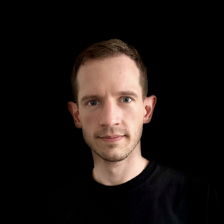

- [mickael.canouil.fr](https://mickael.canouil.fr/)
- pro@mickael.canouil.dev
- [mickaelcanouil](https://www.linkedin.com/in/mickaelcanouil/)
- [@mcanouil](https://github.com/mcanouil/)
- [@MickaelCanouil](https://twitter.com/MickaelCanouil/)
- [@MickaelCanouil@fosstodon.org](https://fosstodon.org/@MickaelCanouil/)